# tutorial: multivariate asymptotic variance estimation

### VAR(1) model

We consider a VAR(1) model defined as
$$X_t = \Phi X_{t-1} + W_t,$$
with $W_t$ i.i.d. $\text{Normal}(0,\Omega)$, and $X_{0}\sim \text{Normal}(0,I)$. We consider the test function $h:x\mapsto x$. The invariant distribution $\pi$ is $\text{Normal}(0,V)$, with
$$\text{vec}(V) = (I_{d^2} - \Phi \otimes
\Phi)^{-1} \text{vec}(\Omega).$$

We take the same parameters as in “Multivariate output analysis for MCMC” by Vats, Flegal & Jones.

```r
dimx <- 5
Phi <- diag(c(0.9, 0.5, 0.1, 0.1, 0.1))
Omega <- matrix(0, nrow = dimx, ncol = dimx)
for (i in 1:dimx){
  for (j in 1:dimx){
    Omega[i,j] <- 0.9^{abs(i-j)}
  }
}
Omega_chol <- chol(Omega)
Omega_chol_inv <- solve(Omega_chol)
## ground truth
vecV <- solve(diag(1,  dimx^2) - kronecker(Phi, Phi), as.numeric(Omega))
V <- matrix(vecV, nrow = dimx)
tmp <- solve(diag(1, dimx) - Phi)
SIGMA <- tmp %*% V + V %*% tmp - V
```

The asymptotic variance $v(P,h)$ in the Central Limit Theorem (CLT) is here:
$$v(P,h) = (I_d - \Phi)^{-1}V + V(I_p -
\Phi)^{-1}-V.$$

### Implementation

We implement the VAR(1) model and a coupling of it.

```r
## Markov kernel
single_kernel <- function(state){
  next_position <- Phi %*% state$position + t(mvnfast::rmvn(1, rep(0, dimx), Omega))
  return(list(position = next_position))
}

## initial distribution Normal(0, 4^2)
rinit <- function(position){
  if (missing(position)){
    position <- t(mvnfast::rmvn(1, rep(0, dimx), diag(1, dimx, dimx)))
  }
  return(list(position = position))
}


## Coupled Markov kernel
## using "reflection-maximal coupling" implemented in the function 'rnorm_reflectionmax'
coupled_kernel <- function(state1, state2){
  nextvalues <- unbiasedpoisson::rmvnorm_reflectionmax(mu1 = Phi %*% state1$position,
                                                       mu2 = Phi %*% state2$position, Omega_chol, Omega_chol_inv)
  return(list(state1 = list(position = nextvalues$xy[,1,drop=F]),
              state2 = list(position = nextvalues$xy[,2,drop=F]),
              identical = nextvalues$identical))
}

## test function x \mapsto x
h <- function(x){ return(x) }

## arbitrary point used in the definition of the fishy function
x_0 <- matrix(rep(0, dimx), ncol = 1)
state_x_0 <- rinit(x_0)
```

### Convergence to stationarity

Histogram of meeting times.

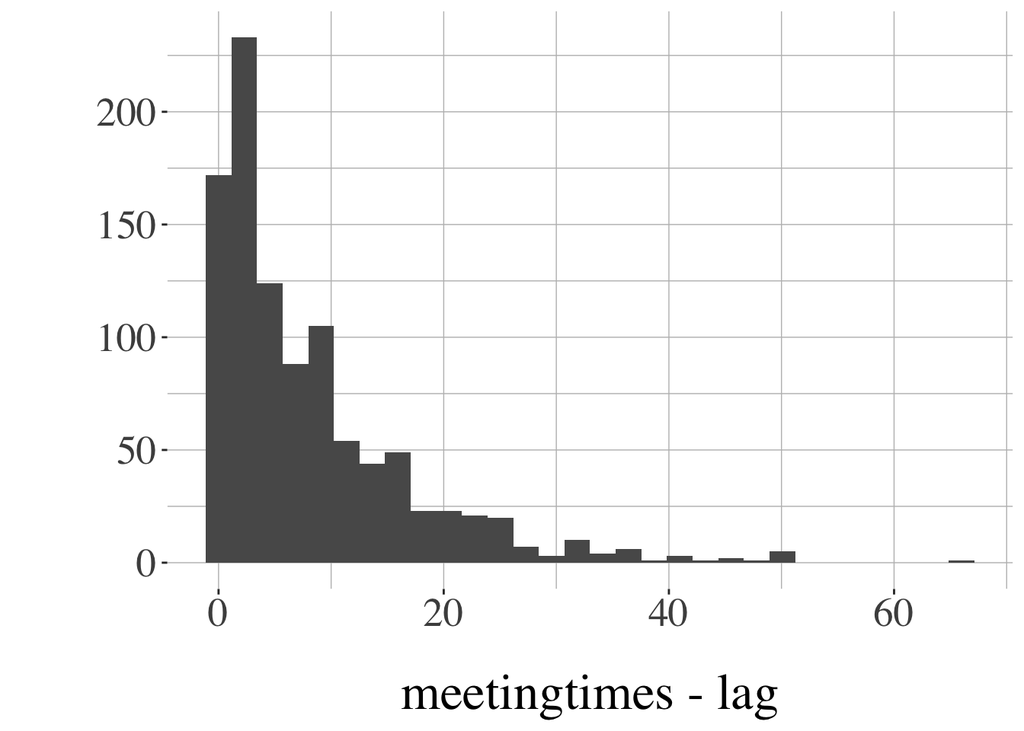

```r
### histogram of meeting times
nrep <- 1e3
lag <- 40
meetingtime_runs <- foreach (irep = 1:nrep) %dorng% {
  sample_meetingtime(single_kernel, coupled_kernel, rinit, lag = lag)
}
meetingtimes <- sapply(meetingtime_runs, function(x) x$meetingtime)
qplot(x=meetingtimes-lag, geom = 'histogram')
```

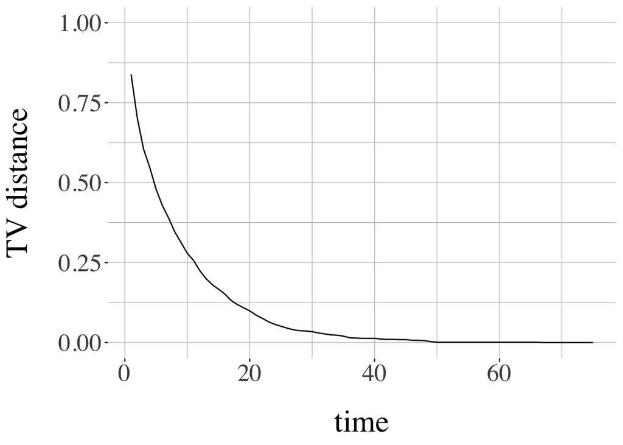

```r
### TV upper bounds
niterations <- 75
ubounds <- sapply(1:niterations, function(t) tv_upper_bound(unlist(meetingtimes), lag, t))
g_tvbounds <- qplot(x = 1:niterations, y = ubounds, geom = "line") +
  ylab("TV distance") + xlab("time") + ylim(0,1)
g_tvbounds
```

### Asymptotic variance estimation

Next we estimate the asymptotic variance with the proposed method.

```r
### lag, k and m
lag <- 40
k <- lag
m <- 5 * k
natoms <- 20
```

We don’t have to change much of the implementation in order to estimate multivariate asymptotic variances. We define an extended test function that includes cross terms.

```r
## redefine test function to compute h_i, i=1,...,dimh but also h_i h_j for i<j
dimh <- 5
hextended <- function(x){
  result <- h(x)
  for (i in 1:(dimh-1)){
    for (j in (i+1):(dimh)){
      result <- c(result, x[i]*x[j])
    }
  }
  return(result)
}
```

Then we re-define the function that takes two runs of `sample_coupled_chains_and_fish` and outputs an unbiased estimator of $v(P,h)$. Thankfully we don’t have to change anything in `sample_coupled_chains_and_fish`.

```r
mv_unbiasedvar_from_tworuns <- function(run1, run2, natoms = 1){
  tictoc::tic("unbiased asymptotic variance estimator")
  ## estimator of pi(h h^T) as average of two estimators
  estim_pih.hT <- matrix(NA, dimh, dimh)
  pi_hsquared_ <- (1/2)*(run1$uestimator_h2 + run2$uestimator_h2)
  diag(estim_pih.hT) <- pi_hsquared_[1:dimh]
  index <- dimh
  for (i in 1:(dimh-1)){
    for (j in (i+1):dimh){
      index <- index + 1
      estim_pih.hT[i,j] <- estim_pih.hT[j,i] <- (1/2)*(run1$uestimator[index] + run2$uestimator[index])
    }
  }
  ## estimator of pi(h) pi(h)^T as product of two independent estimators of pi(h)
  pih_deepbreath_squared_ <- matrix(run1$uestimator[1:dimh], ncol = 1) %*%
    matrix(run2$uestimator[1:dimh], nrow = 1)
  ## estimate of variance under pi
  varh <- estim_pih.hT - pih_deepbreath_squared_
  ## term involving fishy function estimates
  fishyterm1 <- fishyterm2 <- matrix(0, dimh, dimh)
  for (iatom in 1:natoms){
    fishyterm1 <- fishyterm1 + run1$atomcounter * run1$weight_at_atoms[iatom] *
      matrix(run1$h_at_atoms[1:dimh,iatom] - run2$uestimator[1:dimh], ncol = 1) %*%
      matrix(run1$htilde_at_atoms[1:dimh,iatom], nrow = 1)
    fishyterm2 <- fishyterm2 + run2$atomcounter * run2$weight_at_atoms[iatom] *
      matrix(run2$h_at_atoms[1:dimh,iatom] - run1$uestimator[1:dimh], ncol = 1) %*%
      matrix(run2$htilde_at_atoms[1:dimh,iatom], nrow = 1)
  }
  fishyterms <- (fishyterm1 + fishyterm2)/(2*natoms)
  fishyterms <- fishyterms + t(fishyterms)
  ## compute unbiased asymptotic variance estimator
  estimator <- - varh + fishyterms
  ## compute costs
  cost_fishyterms <- cumsum(run1$cost_fishyestimation + run2$cost_fishyestimation)[natoms]
  cost <- run1$costsignedmeasure + run2$costsignedmeasure + cost_fishyterms
  elapsed <- tictoc::toc(quiet = T)
  tictoc::tic.clear()
  return(list(estimator = estimator, fishyterms = fishyterms,
              varh = varh, pih = cbind(run1$uestimator, run2$uestimator),
              cost_fishyterms = cost_fishyterms,
              cost_umcmc = run1$costsignedmeasure + run2$costsignedmeasure,
              cost = cost,
              elapsedtime = as.numeric(elapsed$toc-elapsed$tic)))
}
```

We run $10^3$ estimates, and average the results to estimate $v(P,h)$.

```r
nrep <- 1e3
results <- foreach(irep = 1:nrep) %dorng% {
  run1 <- sample_coupled_chains_and_fish(single_kernel, coupled_kernel, rinit,
                                         hextended, k, m, lag, x_0 = x_0, natoms = natoms)
  run2 <- sample_coupled_chains_and_fish(single_kernel, coupled_kernel, rinit,
                                         hextended, k, m, lag, x_0 = x_0, natoms = natoms)
  mv_unbiasedvar_from_tworuns(run1, run2, natoms)
}
results_array <- array(data=0, dim = c(nrep, dimh, dimh))
for (irep in 1:nrep){
  results_array[irep,,] <- results[[irep]]$estimator
}
estimate <- apply(results_array, c(2,3), mean)
print(round(estimate, 2))
```

```
##       [,1]  [,2] [,3] [,4] [,5]
## [1,] 98.73 17.70 8.85 7.99 7.24
## [2,] 17.70  3.97 1.99 1.80 1.62
## [3,]  8.85  1.99 1.23 1.11 1.01
## [4,]  7.99  1.80 1.11 1.23 1.11
## [5,]  7.24  1.62 1.01 1.12 1.24
```

We compare with the exact value of the asymptotic variance.

```r
print(round(SIGMA, 2))
```

```
##        [,1]  [,2] [,3] [,4] [,5]
## [1,] 100.00 18.00 9.00 8.10 7.29
## [2,]  18.00  4.00 2.00 1.80 1.62
## [3,]   9.00  2.00 1.23 1.11 1.00
## [4,]   8.10  1.80 1.11 1.23 1.11
## [5,]   7.29  1.62 1.00 1.11 1.23
```

Each of the $10^3$ estimates was obtained for a certain cost. Let’s look at the histogram of the cost.

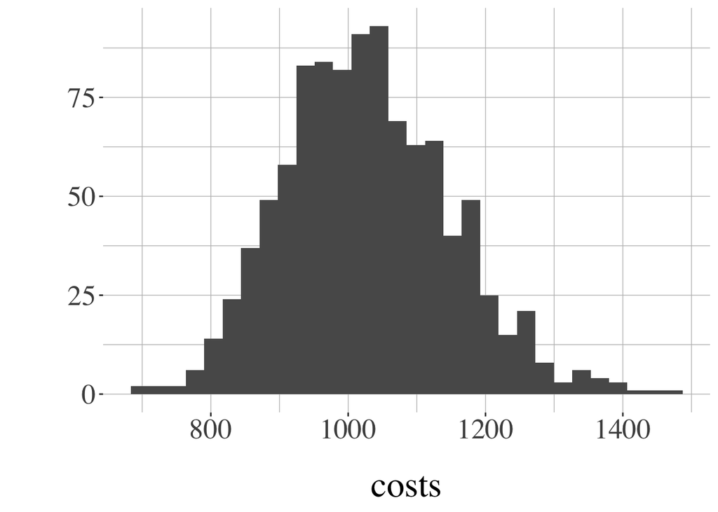

```r
costs <- sapply(results, function(x) x$cost)
qplot(x=costs, geom = 'histogram')
```